# Homework 01

Author

Prerith Arunkumar (prerith2)

Least squares, the Gaussian likelihood, nonconvex optimization, collinearity, data preparation, and selection bias.

```python
import numpy as np
import pandas as pd
import matplotlib.pyplot as plt
from scipy.linalg import qr, solve_triangular
from scipy.optimize import minimize

np.set_printoptions(precision=6, suppress=True)
pd.set_option("display.width", 120)
```

## Question 1 (Least squares and matrix calculations)

Set the random seed to 43201. Generate $n = 100$ observations with $p = 5$ predictors,

$$x_{ij} \overset{\text{iid}}{\sim} N(0,1), \qquad \varepsilon_i \overset{\text{iid}}{\sim} N(0, 0.7^2),$$

with $\mathbf X = [\mathbf 1 \ \ \mathbf x_1 \ \cdots \ \mathbf x_5]$, $\boldsymbol\beta = (3, 1.4, -0.9, 0.7, 0, 1.1)^{\mathsf T}$, and $\mathbf y = \mathbf X \boldsymbol\beta + \boldsymbol\varepsilon$.

### (a) Generate the data; report the dimensions and rank of $\mathbf X$; compute $\widehat{\boldsymbol\beta}$

```python
rng = np.random.default_rng(43201)

n, p = 100, 5
sigma_true = 0.7

X_pred = rng.normal(0.0, 1.0, size=(n, p))          # the five predictors
eps    = rng.normal(0.0, sigma_true, size=n)        # the errors

X = np.column_stack([np.ones(n), X_pred])           # add the intercept column
beta_true = np.array([3.0, 1.4, -0.9, 0.7, 0.0, 1.1])
y = X @ beta_true + eps

print("dim(X) =", X.shape)
print("rank(X) =", np.linalg.matrix_rank(X), " (full column rank:", np.linalg.matrix_rank(X) == X.shape[1], ")")
```

```
dim(X) = (100, 6)
rank(X) = 6  (full column rank: True )
```

`np.linalg.lstsq` solves the least-squares problem through an SVD-based driver, so $\widehat{\boldsymbol\beta}$ is obtained without ever forming $\mathbf X^{\mathsf T}\mathbf X$ or inverting it. Standard errors below are computed from the $\mathbf R$ factor of a QR decomposition (again no explicit inverse of $\mathbf X^{\mathsf T}\mathbf X$).

```python
beta_hat, _, rank_ls, sing_vals = np.linalg.lstsq(X, y, rcond=None)

# standard errors via the QR factor: (X'X)^{-1} = R^{-1} R^{-T}
Q, R = qr(X, mode="economic")
Rinv = solve_triangular(R, np.eye(R.shape[0]))
xtx_inv_diag = np.sum(Rinv**2, axis=1)

resid_tmp = y - X @ beta_hat
sigma2_unbiased = resid_tmp @ resid_tmp / (n - X.shape[1])
se = np.sqrt(sigma2_unbiased * xtx_inv_diag)

coef_table = pd.DataFrame({
    "true beta": beta_true,
    "beta hat": beta_hat,
    "difference": beta_hat - beta_true,
    "std. error": se,
    "diff / SE": (beta_hat - beta_true) / se,
}, index=["intercept", "x1", "x2", "x3", "x4", "x5"])

print("rank reported by lstsq:", rank_ls)
coef_table.round(4)
```

```
rank reported by lstsq: 6
```

|  | true beta | beta hat | difference | std. error | diff / SE |
| --- | --- | --- | --- | --- | --- |
| intercept | 3.0 | 2.9731 | -0.0269 | 0.0689 | -0.3908 |
| x1 | 1.4 | 1.3240 | -0.0760 | 0.0722 | -1.0520 |
| x2 | -0.9 | -0.8415 | 0.0585 | 0.0589 | 0.9931 |
| x3 | 0.7 | 0.7204 | 0.0204 | 0.0687 | 0.2976 |
| x4 | 0.0 | -0.0831 | -0.0831 | 0.0646 | -1.2873 |
| x5 | 1.1 | 1.1651 | 0.0651 | 0.0646 | 1.0069 |

**Comparison.** $\mathbf X$ is $100 \times 6$ and has rank 6, so it is of full column rank and the least-squares solution is unique. Every estimate lands close to the coefficient that generated the data: the largest discrepancy is $0.083$, on $\beta_4$, whose true value is $0$. Dividing each difference by its standard error, all six estimates sit within about $1.3$ standard errors of the truth, which is exactly what sampling variation at $n = 100$ and $\sigma = 0.7$ should produce. In particular the estimate of the null coefficient $\beta_4 = 0$ is not exactly zero — least squares has no mechanism to return an exact zero — but it is statistically indistinguishable from zero.

### (b) Fitted values, residuals, and training RMSE

```python
fitted = X @ beta_hat
r = y - fitted
rss = r @ r
rmse_train = np.sqrt(np.mean(r**2))

print(f"RSS               = {rss:.6f}")
print(f"training RMSE     = {rmse_train:.6f}")
print(f"true sigma        = {sigma_true:.6f}")
print(f"mean of residuals = {r.mean():.3e}")
print("\nfirst 5 observations:")
pd.DataFrame({"y": y[:5], "fitted": fitted[:5], "residual": r[:5]}).round(4)
```

```
RSS               = 41.775504
training RMSE     = 0.646340
true sigma        = 0.700000
mean of residuals = 1.010e-15

first 5 observations:
```

|  | y | fitted | residual |
| --- | --- | --- | --- |
| 0 | 1.4994 | 0.4284 | 1.0710 |
| 1 | 2.9202 | 2.6798 | 0.2404 |
| 2 | 6.6809 | 6.6011 | 0.0798 |
| 3 | -2.0687 | -1.9718 | -0.0970 |
| 4 | 2.6943 | 2.2709 | 0.4234 |

The training RMSE is $0.6463$, slightly below the true noise level $\sigma = 0.7$. That is expected: the training RMSE divides by $n$ rather than $n - p - 1$, and the fitted coefficients were chosen to minimize exactly this quantity on this sample, so it is an optimistically small estimate of the noise scale.

### (c) $\lVert \mathbf X^{\mathsf T} \mathbf r \rVert_\infty$

```python
grad_norm = np.max(np.abs(X.T @ r))
print(f"||X' r||_inf = {grad_norm:.3e}")
print(f"scale for comparison, ||X' y||_inf = {np.max(np.abs(X.T @ y)):.3f}")
```

```
||X' r||_inf = 1.479e-12
scale for comparison, ||X' y||_inf = 305.210
```

**Why this is essentially zero.** The least-squares criterion $S(\boldsymbol\beta) = \lVert \mathbf y - \mathbf X\boldsymbol\beta\rVert^2$ has gradient $-2\mathbf X^{\mathsf T}(\mathbf y - \mathbf X\boldsymbol\beta)$. Setting it to zero gives the normal equations $\mathbf X^{\mathsf T}(\mathbf y - \mathbf X\widehat{\boldsymbol\beta}) = \mathbf X^{\mathsf T}\mathbf r = \mathbf 0$, so the exact minimizer makes this vector identically zero. The computed value, on the order of $10^{-12}$, is pure floating-point rounding: it is roughly machine epsilon relative to the scale of $\mathbf X^{\mathsf T}\mathbf y$, which confirms the solver returned an accurate solution.

## Question 2 (Gaussian likelihood for linear regression)

With $\mathbf Y \mid \mathbf X \sim N_n(\mathbf X\boldsymbol\beta, \sigma^2 \mathbf I_n)$,

$$\ell(\boldsymbol\beta, \sigma^2) = -\frac{n}{2}\log(2\pi\sigma^2) - \frac{1}{2\sigma^2}(\mathbf y - \mathbf X\boldsymbol\beta)^{\mathsf T}(\mathbf y - \mathbf X\boldsymbol\beta).$$

### (a) For fixed $\sigma^2$, maximizing $\ell$ over $\boldsymbol\beta$ is minimizing the RSS

Write $\mathrm{RSS}(\boldsymbol\beta) = (\mathbf y - \mathbf X\boldsymbol\beta)^{\mathsf T}(\mathbf y - \mathbf X\boldsymbol\beta)$. Then

$$\ell(\boldsymbol\beta, \sigma^2) = \underbrace{-\frac{n}{2}\log(2\pi\sigma^2)}_{\text{free of } \boldsymbol\beta} \;-\; \frac{1}{2\sigma^2}\,\mathrm{RSS}(\boldsymbol\beta).$$

For fixed $\sigma^2$ the first term is a constant in $\boldsymbol\beta$, and the second is $\mathrm{RSS}(\boldsymbol\beta)$ multiplied by the strictly negative constant $-1/(2\sigma^2)$. A strictly decreasing affine transformation reverses the ordering of a function’s values, so $\boldsymbol\beta$ maximizes $\ell$ if and only if it minimizes $\mathrm{RSS}(\boldsymbol\beta)$ — and the argmax does not depend on the value of $\sigma^2$.

**Implication.** Under the Gaussian model with i.i.d. homoscedastic errors, the maximum-likelihood estimate of $\boldsymbol\beta$ *is* the least-squares estimate: $\widehat{\boldsymbol\beta}_{\mathrm{MLE}} = \widehat{\boldsymbol\beta}_{\mathrm{OLS}} = \widehat{\boldsymbol\beta}$, which here is unique because $\mathbf X$ has full column rank. Least squares, normally motivated as a geometric projection, is thus given a probabilistic justification; the equivalence is a consequence of Gaussian errors with constant variance and would fail for other error distributions.

### (b) MLE of $\sigma^2$ for fixed $\boldsymbol\beta$

Treat $v = \sigma^2$ as the argument and differentiate:

$$\ell(\boldsymbol\beta, v) = -\frac{n}{2}\log(2\pi) - \frac{n}{2}\log v - \frac{\mathrm{RSS}(\boldsymbol\beta)}{2v},
\qquad
\frac{\partial \ell}{\partial v} = -\frac{n}{2v} + \frac{\mathrm{RSS}(\boldsymbol\beta)}{2v^{2}}.$$

Setting the derivative to zero and multiplying by $2v^2 > 0$ gives $-nv + \mathrm{RSS}(\boldsymbol\beta) = 0$, so

$$\widehat\sigma^2_{\mathrm{MLE}} = \frac{\mathrm{RSS}(\boldsymbol\beta)}{n}.$$

This is a maximum: $\partial\ell/\partial v > 0$ for $v < \mathrm{RSS}/n$ and $< 0$ for $v > \mathrm{RSS}/n$, so $\ell$ increases then decreases. Equivalently $\partial^2\ell/\partial v^2 = n/(2v^2) - \mathrm{RSS}/v^3$, which equals $-n^3/(2\,\mathrm{RSS}^2) < 0$ at the stationary point. Evaluating at $\boldsymbol\beta = \widehat{\boldsymbol\beta}$ gives the joint MLE $\widehat\sigma^2_{\mathrm{MLE}} = \mathrm{RSS}(\widehat{\boldsymbol\beta})/n$.

```python
p_full = X.shape[1]           # 6 = intercept + 5 predictors

sigma2_mle      = rss / n
sigma2_unbiased = rss / (n - p_full)

print(f"RSS at beta_hat                        = {rss:.6f}")
print(f"sigma^2 MLE      = RSS / n     = RSS/{n}  = {sigma2_mle:.6f}   (sd = {np.sqrt(sigma2_mle):.6f})")
print(f"sigma^2 unbiased = RSS / (n-p) = RSS/{n - p_full}   = {sigma2_unbiased:.6f}   (sd = {np.sqrt(sigma2_unbiased):.6f})")
print(f"true sigma^2                           = {sigma_true**2:.6f}   (sd = {sigma_true:.6f})")
print(f"\nratio unbiased / MLE = {sigma2_unbiased / sigma2_mle:.6f}   vs   n/(n-p) = {n/(n - p_full):.6f}")
```

```
RSS at beta_hat                        = 41.775504
sigma^2 MLE      = RSS / n     = RSS/100  = 0.417755   (sd = 0.646340)
sigma^2 unbiased = RSS / (n-p) = RSS/94   = 0.444420   (sd = 0.666649)
true sigma^2                           = 0.490000   (sd = 0.700000)

ratio unbiased / MLE = 1.063830   vs   n/(n-p) = 1.063830
```

**Why the denominators differ.** Both estimates use the same numerator, $\mathrm{RSS}(\widehat{\boldsymbol\beta})$; they differ only in whether the divisor is $n$ or $n - p - 1 = 94$. The residual vector is not the error vector: it is $\mathbf r = (\mathbf I - \mathbf H)\boldsymbol\varepsilon$, the projection of $\boldsymbol\varepsilon$ onto the $(n - p - 1)$-dimensional space orthogonal to the columns of $\mathbf X$. Fitting six coefficients uses up six dimensions’ worth of the noise, so $E[\mathrm{RSS}] = (n - p - 1)\sigma^2 = 94\sigma^2$, not $n\sigma^2$. Dividing by $n$ therefore gives $E[\widehat\sigma^2_{\mathrm{MLE}}] = \frac{94}{100}\sigma^2 < \sigma^2$: the MLE is biased downward, systematically understating the noise by 6% here. Dividing by the residual degrees of freedom $n-p-1$ corrects exactly for this. Numerically, $0.4178$ versus $0.4444$ — the unbiased estimate is nearer the true $\sigma^2 = 0.49$. Maximum likelihood is not required to be unbiased, and here it is not; the two agree asymptotically since $n/(n-p-1) \to 1$.

### (c) Profile of $\ell$ along the $\mathbf x_2$ coordinate

With $\mathbf e_{x_2} = (0,0,1,0,0,0)^{\mathsf T}$, plot $\ell(\widehat{\boldsymbol\beta} + t\,\mathbf e_{x_2}, \widehat\sigma^2_{\mathrm{MLE}})$ for $t \in [-1.25, 1.25]$.

```
grid maximizer     t* = 0.000000
log-likelihood at t*  = -98.250851
log-likelihood at t=0 = -98.250851
beta_hat[x2] = -0.841489  ->  beta_hat[x2] + t* = -0.841489
```

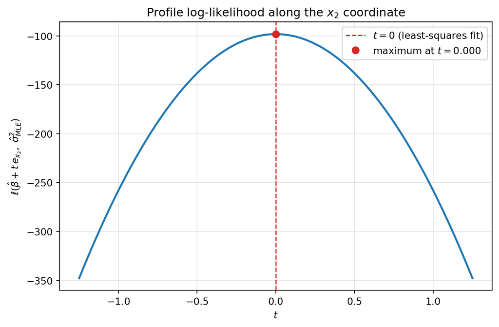

```python
def loglik(b, s2):
    resid = y - X @ b
    return -n / 2 * np.log(2 * np.pi * s2) - (resid @ resid) / (2 * s2)

e_x2 = np.zeros(p_full)
e_x2[2] = 1.0                       # index 2 = the x2 column (0 = intercept)

t_grid = np.linspace(-1.25, 1.25, 501)
ll_grid = np.array([loglik(beta_hat + t * e_x2, sigma2_mle) for t in t_grid])

t_star = t_grid[np.argmax(ll_grid)]
print(f"grid maximizer     t* = {t_star:.6f}")
print(f"log-likelihood at t*  = {ll_grid.max():.6f}")
print(f"log-likelihood at t=0 = {loglik(beta_hat, sigma2_mle):.6f}")
print(f"beta_hat[x2] = {beta_hat[2]:.6f}  ->  beta_hat[x2] + t* = {beta_hat[2] + t_star:.6f}")

fig, ax = plt.subplots(figsize=(8, 5))
ax.plot(t_grid, ll_grid, color="#1f77b4", lw=2)
ax.axvline(0.0, color="#d62728", ls="--", lw=1.2, label="$t = 0$ (least-squares fit)")
ax.plot([t_star], [ll_grid.max()], "o", color="#d62728", ms=7, label=f"maximum at $t = {t_star:.3f}$")
ax.set_xlabel("$t$")
ax.set_ylabel(r"$\ell(\hat\beta + t\,e_{x_2},\ \hat\sigma^2_{MLE})$")
ax.set_title("Profile log-likelihood along the $x_2$ coordinate")
ax.legend()
ax.grid(alpha=0.3)
plt.show()
```

**Where the maximum occurs and why.** The curve peaks at $t = 0$, that is, exactly at $\widehat{\boldsymbol\beta}$ itself, with $\ell = -98.251$. This agrees with the least-squares result for the reason established in part (a): with $\sigma^2$ held fixed, $\ell$ is a strictly decreasing affine function of $\mathrm{RSS}$, and $\mathrm{RSS}$ is minimized over *all* of $\mathbb R^6$ at $\widehat{\boldsymbol\beta}$. A line through the global minimizer must attain its minimum RSS — hence its maximum $\ell$ — at the point where it passes through that minimizer, namely $t = 0$.

The shape is also informative. Expanding, $\mathrm{RSS}(\widehat{\boldsymbol\beta} + t\,\mathbf e) = \mathrm{RSS}(\widehat{\boldsymbol\beta}) + t^2\,\mathbf e^{\mathsf T}\mathbf X^{\mathsf T}\mathbf X\mathbf e$; the cross term $-2t\,\mathbf e^{\mathsf T}\mathbf X^{\mathsf T}\mathbf r$ vanishes by the orthogonality established in Question 1(c). So the profile is an exact downward parabola centered at $t=0$, with curvature $-\lVert \mathbf x_2 \rVert^2 / \sigma^2$. The sharpness of that parabola is the observed information for $\beta_{x_2}$: a steep peak means the data pin the coefficient down tightly, a flat one means they do not — a point that returns forcefully in Question 4.

## Question 3 (Starting values in nonconvex optimization)

$$f(x) = \exp(1.5x) - 3(x+6)^2 - 0.05x^3, \qquad f'(x) = 1.5\exp(1.5x) - 6(x+6) - 0.15x^2.$$

### (a) Plot $f$ over $[-40, 7]$

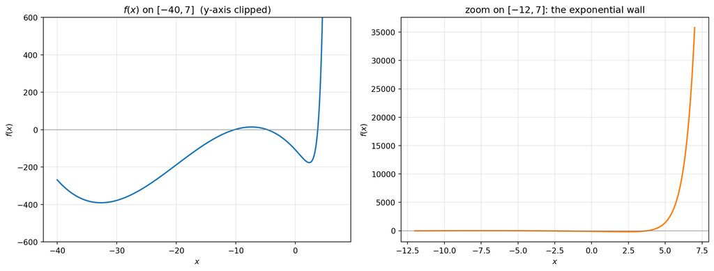

```
approximate stationary points (grid): [-32.654  -7.362   2.346]
f(-40) = -268.000,   f(7) = 35791.353
```

```python
def f(x):
    return np.exp(1.5 * x) - 3 * (x + 6)**2 - 0.05 * x**3

def fprime(x):
    return 1.5 * np.exp(1.5 * x) - 6 * (x + 6) - 0.15 * x**2

xs = np.linspace(-40, 7, 4000)
fs = f(xs)

fig, axes = plt.subplots(1, 2, figsize=(13, 5))

axes[0].plot(xs, fs, color="#1f77b4", lw=1.8)
axes[0].set_ylim(-600, 600)
axes[0].set_title("$f(x)$ on $[-40, 7]$  (y-axis clipped)")
axes[0].set_xlabel("$x$"); axes[0].set_ylabel("$f(x)$")
axes[0].axhline(0, color="gray", lw=0.6)
axes[0].grid(alpha=0.3)

zoom = (xs >= -12) & (xs <= 7)
axes[1].plot(xs[zoom], fs[zoom], color="#ff7f0e", lw=1.8)
axes[1].set_title("zoom on $[-12, 7]$: the exponential wall")
axes[1].set_xlabel("$x$"); axes[1].set_ylabel("$f(x)$")
axes[1].axhline(0, color="gray", lw=0.6)
axes[1].grid(alpha=0.3)

plt.tight_layout(); plt.show()

# locate the stationary points on a fine grid for reference
sign_change = np.where(np.diff(np.sign(fprime(xs))) != 0)[0]
print("approximate stationary points (grid):", np.round(xs[sign_change], 3))
print(f"f(-40) = {f(-40):.3f},   f(7) = {f(7):.3f}")
```

**Features that matter for optimization.**

1. **The function is nonconvex and has multiple stationary points.** On the plotted interval there are three: a local minimum near $x \approx -32.6$, a local maximum near $x \approx -7.4$, and a second local minimum near $x \approx 2.35$. Any gradient-based method converges to whichever basin its starting point lies in, so the answer depends on $x^{(0)}$.
2. **Two separate basins of attraction, split by the local maximum at $x \approx -7.4$.** Roughly, starts to the left of $-7.4$ descend to the left minimum; starts to the right descend to the right minimum.
3. **Wildly different scales across the domain.** For $x \lesssim -10$ the exponential term is numerically negligible and $f$ behaves like a cubic of magnitude in the hundreds; near $x = 7$, $\exp(1.5x) \approx 3.6\times10^4$ and the function rises almost vertically. The curvature $f''$ therefore changes by orders of magnitude, which makes a single fixed step size hopeless and makes line searches essential — BFGS’s own curvature estimate must adapt as it moves.
4. **Overflow risk on the right.** A line search that overshoots to, say, $x = 500$ would evaluate $\exp(750)$ and return `inf`. The exponential wall punishes aggressive steps taken from the right-hand basin.
5. **The two local minima have very different objective values** ($-390.4$ versus $-175.9$), so landing in the wrong basin is not a harmless difference — it costs more than 200 units of objective.

### (b) BFGS from $x^{(0)} = -15$ and $x^{(0)} = 0$

```python
def run_bfgs(x0):
    res = minimize(
        fun=lambda v: f(v[0]),
        x0=np.array([float(x0)]),
        jac=lambda v: np.array([fprime(v[0])]),
        method="BFGS",
    )
    x_end = res.x[0]
    return {
        "start": float(x0),
        "final_x": x_end,
        "f_final": f(x_end),
        "abs_grad": abs(fprime(x_end)),
        "converged": bool(res.success),
        "message": res.message,
        "iterations": res.nit,
        "f_evals": res.nfev,
    }

results = [run_bfgs(-15), run_bfgs(0)]

for res in results:
    print(f"start x0 = {res['start']:>6.1f}  ->  x = {res['final_x']:>12.6f}   "
          f"f(x) = {res['f_final']:>12.6f}   |f'(x)| = {res['abs_grad']:.3e}   "
          f"converged = {res['converged']}")
    print(f"{'':>17}({res['message']}; {res['iterations']} iterations, {res['f_evals']} function evaluations)")

runs = pd.DataFrame(results).rename(columns={
    "start": "start x0", "final_x": "final x", "f_final": "f(x)", "abs_grad": "|f'(x)|",
    "f_evals": "f evals",
})
runs[["start x0", "final x", "f(x)", "|f'(x)|", "converged", "iterations", "f evals"]]
```

```
start x0 =  -15.0  ->  x =   -32.649111   f(x) =  -390.385770   |f'(x)| = 2.842e-14   converged = True
                 (Optimization terminated successfully.; 2 iterations, 6 function evaluations)
start x0 =    0.0  ->  x =     2.349967   f(x) =  -175.862620   |f'(x)| = 8.127e-06   converged = True
                 (Optimization terminated successfully.; 5 iterations, 9 function evaluations)
```

|  | start x0 | final x | f(x) | \|f'(x)\| | converged | iterations | f evals |
| --- | --- | --- | --- | --- | --- | --- | --- |
| 0 | -15.0 | -32.649111 | -390.38577 | 2.842171e-14 | True | 2 | 6 |
| 1 | 0.0 | 2.349967 | -175.86262 | 8.126811e-06 | True | 5 | 9 |

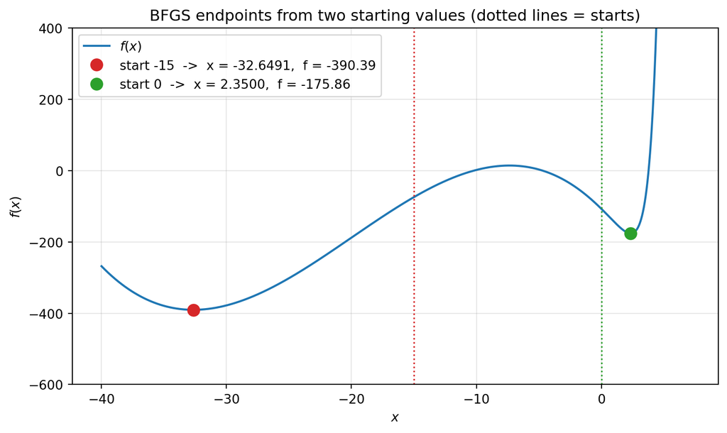

```python
# both solutions marked on the curve
fig, ax = plt.subplots(figsize=(9, 5))
ax.plot(xs, fs, color="#1f77b4", lw=1.6, label="$f(x)$")
ax.set_ylim(-600, 400)
for x0, col in [(-15.0, "#d62728"), (0.0, "#2ca02c")]:
    xr = run_bfgs(x0)["final_x"]
    ax.axvline(x0, color=col, ls=":", lw=1.2)
    ax.plot([xr], [f(xr)], "o", color=col, ms=9,
            label=f"start {x0:g}  ->  x = {xr:.4f},  f = {f(xr):.2f}")
ax.set_xlabel("$x$"); ax.set_ylabel("$f(x)$")
ax.set_title("BFGS endpoints from two starting values (dotted lines = starts)")
ax.legend(loc="upper left"); ax.grid(alpha=0.3)
plt.show()
```

| start $x^{(0)}$ | final $x$ | $f(x)$ | $\lvert f'(x)\rvert$ | converged |
| --- | --- | --- | --- | --- |
| $-15$ | $-32.649111$ | $-390.385770$ | $2.8\times10^{-14}$ | yes |
| $0$ | $2.349967$ | $-175.862620$ | $8.1\times10^{-6}$ | yes |

Both runs report successful convergence, and in both cases the gradient at the returned point is numerically zero, so each is a legitimate stationary point — indeed a local minimum, since $f'' > 0$ at both.

### (c) Why the runs differ

**Why different answers.** BFGS is a *local* descent method. It is guaranteed only to find a point where the gradient vanishes, and which one it finds is determined entirely by which basin of attraction contains $x^{(0)}$. The local maximum at $x \approx -7.4$ separates the domain into two basins. Starting at $x^{(0)} = -15$ puts the optimizer to the left of that ridge, where $f' > 0$, so descent moves left and settles in the left minimum at $x = -32.649$. Starting at $x^{(0)} = 0$ puts it to the right, where the local gradient sends it right, into the minimum at $x = 2.350$. Neither run can see over the ridge: the algorithm only ever uses local function and gradient information, and there is no mechanism in BFGS to escape a basin once it is in one. Both answers are “correct” as solutions to the first-order condition; they are answers to a local question, not a global one.

**Which is lower.** The run from $x^{(0)} = -15$, at $f(-32.649) = -390.386$, is lower by $214.5$ than the run from $x^{(0)} = 0$, at $f(2.350) = -175.863$.

**What more would be needed to claim a global minimum.** A converged optimizer plus a zero gradient establishes only local optimality. To argue globally one would want:

- **Many starting values.** A multi-start over a grid or random draws covering the region of interest, checking that no start produces a lower value; or a global method (simulated annealing, basin hopping, DIRECT).
- **A dense grid or bracketing evaluation** of $f$ over the domain to confirm no lower region was missed — and, since $f$ is smooth, enumeration of all roots of $f'$ with a classification of each by the sign of $f''$.
- **Control of the behavior outside the plotted window.** The interval $[-40, 7]$ is a plotting choice, not part of the problem. As $x \to +\infty$, $\exp(1.5x)$ dominates and $f \to +\infty$; as $x \to -\infty$, $-0.05x^3 \to +\infty$ and again $f \to +\infty$. So $f$ is coercive, only finitely many stationary points exist, and the global minimum over $\mathbb R$ is attained — it is the smaller of the two local minima, $f(-32.649) = -390.386$. Without an argument of this kind (or a proof of convexity, which fails here), one can only report the best point found.

## Question 4 (Nearly collinear predictors)

Set seed 43202, draw $u_i \overset{\text{iid}}{\sim} N(0,1)$, and define

$$\mathbf x_6 = \mathbf x_1 + 10^{-4}\mathbf u, \qquad \mathbf X_+ = [\mathbf X \ \ \mathbf x_6], \qquad \mathbf y^\star = \mathbf y + 10^{-3}\mathbf u.$$

### (a) Fit $\mathbf y$ on $\mathbf X$ and on $\mathbf X_+$

```python
rng2 = np.random.default_rng(43202)
u = rng2.normal(0.0, 1.0, size=n)

x1 = X[:, 1]
x6 = x1 + 1e-4 * u
X_plus = np.column_stack([X, x6])
y_star = y + 1e-3 * u

cols = ["intercept", "x1", "x2", "x3", "x4", "x5", "x6"]

beta_X, *_      = np.linalg.lstsq(X, y, rcond=None)
beta_Xplus, *_  = np.linalg.lstsq(X_plus, y, rcond=None)

rmse = lambda a, b: float(np.sqrt(np.mean((a - b)**2)))
rmse_X     = rmse(y, X @ beta_X)
rmse_Xplus = rmse(y, X_plus @ beta_Xplus)

print(f"correlation(x1, x6) = {np.corrcoef(x1, x6)[0, 1]:.12f}")
print()
print(f"{'design':<10}{'condition number':>20}{'training RMSE':>18}")
print(f"{'X':<10}{np.linalg.cond(X):>20.4f}{rmse_X:>18.6f}")
print(f"{'X+':<10}{np.linalg.cond(X_plus):>20.4f}{rmse_Xplus:>18.6f}")
print()
print(f"augmented fit:  coefficient of x1 = {beta_Xplus[1]:>14.4f}")
print(f"                coefficient of x6 = {beta_Xplus[6]:>14.4f}")
print(f"                their sum         = {beta_Xplus[1] + beta_Xplus[6]:>14.4f}"
      f"   (vs {beta_X[1]:.4f} for x1 alone in the X fit)")

pd.DataFrame({"X fit": np.append(beta_X, np.nan), "X+ fit": beta_Xplus}, index=cols).round(4)
```

```
correlation(x1, x6) = 0.999999994610

design        condition number     training RMSE
X                       1.4525          0.646340
X+                  20339.8358          0.633956

augmented fit:  coefficient of x1 =     -1329.7430
                coefficient of x6 =      1331.0601
                their sum         =         1.3171   (vs 1.3240 for x1 alone in the X fit)
```

|  | X fit | X+ fit |
| --- | --- | --- |
| intercept | 2.9731 | 2.9585 |
| x1 | 1.3240 | -1329.7430 |
| x2 | -0.8415 | -0.8427 |
| x3 | 0.7204 | 0.7275 |
| x4 | -0.0831 | -0.1028 |
| x5 | 1.1651 | 1.1486 |
| x6 | NaN | 1331.0601 |

The condition number jumps from $1.45$ for $\mathbf X$ — essentially perfectly conditioned, as one expects from independent standard normal columns — to $2.03\times10^4$ for $\mathbf X_+$, four orders of magnitude worse, because $\mathbf x_6$ is $\mathbf x_1$ plus a perturbation of relative size $10^{-4}$ (their correlation is $0.99999999\ldots$). The training RMSE barely moves, from $0.646340$ to $0.633956$: the extra column adds a degree of freedom and so must weakly reduce RSS, but it carries almost no new information. Meanwhile the individual coefficients explode to $-1329.74$ on $\mathbf x_1$ and $+1331.06$ on $\mathbf x_6$ — enormous, of opposite sign, and summing to $1.3171$, which is close to the single $\mathbf x_1$ coefficient $1.3240$ from the unaugmented fit. The *sum* is well determined; the individual pieces are not.

### (b) Fit $\mathbf y^\star$ on $\mathbf X_+$

```python
beta_star, *_ = np.linalg.lstsq(X_plus, y_star, rcond=None)

fit_y      = X_plus @ beta_Xplus
fit_y_star = X_plus @ beta_star
d = fit_y_star - fit_y

comp = pd.DataFrame({
    "fit of y":      beta_Xplus,
    "fit of y*":     beta_star,
    "change":        beta_star - beta_Xplus,
}, index=cols)

print("coefficient changes on the two collinear columns:")
print(f"  x1: {beta_Xplus[1]:>12.4f}  ->  {beta_star[1]:>12.4f}   change = {beta_star[1] - beta_Xplus[1]:>+10.6f}")
print(f"  x6: {beta_Xplus[6]:>12.4f}  ->  {beta_star[6]:>12.4f}   change = {beta_star[6] - beta_Xplus[6]:>+10.6f}")
print(f"  sum of the two: {beta_Xplus[1] + beta_Xplus[6]:.6f}  ->  {beta_star[1] + beta_star[6]:.6f}"
      f"   (change = {(beta_star[1] + beta_star[6]) - (beta_Xplus[1] + beta_Xplus[6]):.3e})")
print()
print("fitted-value comparison:")
print(f"  root mean squared difference = {np.sqrt(np.mean(d**2)):.6e}")
print(f"  maximum absolute difference  = {np.max(np.abs(d)):.6e}")
print(f"  (for scale) sd of y          = {y.std():.4f}")

comp.round(4)
```

```
coefficient changes on the two collinear columns:
  x1:   -1329.7430  ->    -1339.7430   change = -10.000000
  x6:    1331.0601  ->     1341.0601   change = +10.000000
  sum of the two: 1.317123  ->  1.317123   (change = 2.274e-13)

fitted-value comparison:
  root mean squared difference = 9.749803e-04
  maximum absolute difference  = 2.351165e-03
  (for scale) sd of y          = 2.3127
```

|  | fit of y | fit of y* | change |
| --- | --- | --- | --- |
| intercept | 2.9585 | 2.9585 | 0.0 |
| x1 | -1329.7430 | -1339.7430 | -10.0 |
| x2 | -0.8427 | -0.8427 | 0.0 |
| x3 | 0.7275 | 0.7275 | 0.0 |
| x4 | -0.1028 | -0.1028 | -0.0 |
| x5 | 1.1486 | 1.1486 | 0.0 |
| x6 | 1331.0601 | 1341.0601 | 10.0 |

### (c) Explaining this with $\mathbf y^\star - \mathbf y = 10(\mathbf x_6 - \mathbf x_1)$

```python
print("identity check, max |(y* - y) - 10 (x6 - x1)| =",
      f"{np.max(np.abs((y_star - y) - 10 * (x6 - x1))):.3e}")

print("\npredicted coefficient change from the identity:  x1: -10, x6: +10")
print(f"observed:                                        x1: {beta_star[1]-beta_Xplus[1]:.6f}, "
      f"x6: {beta_star[6]-beta_Xplus[6]:.6f}")

print(f"\nnorms:  ||y* - y||   = {np.linalg.norm(y_star - y):.6f}")
print(f"        ||x6 - x1||  = {np.linalg.norm(x6 - x1):.6e}   (smaller by a factor of "
      f"{np.linalg.norm(y_star-y)/np.linalg.norm(x6-x1):.0f})")
print(f"        ||x1||       = {np.linalg.norm(x1):.6f}")

print("\nfitted values also shift by exactly 10 (x6 - x1):")
print(f"  max |(fit* - fit) - 10 (x6 - x1)| = {np.max(np.abs(d - 10 * (x6 - x1))):.3e}")
```

```
identity check, max |(y* - y) - 10 (x6 - x1)| = 1.998e-15

predicted coefficient change from the identity:  x1: -10, x6: +10
observed:                                        x1: -10.000000, x6: 10.000000

norms:  ||y* - y||   = 0.009750
        ||x6 - x1||  = 9.749803e-04   (smaller by a factor of 10)
        ||x1||       = 9.343366

fitted values also shift by exactly 10 (x6 - x1):
  max |(fit* - fit) - 10 (x6 - x1)| = 1.190e-12
```

**The explanation.** Since $\mathbf y^\star - \mathbf y = 10^{-3}\mathbf u$ and $\mathbf x_6 - \mathbf x_1 = 10^{-4}\mathbf u$,

$$\mathbf y^\star - \mathbf y = 10\,(\mathbf x_6 - \mathbf x_1),$$

verified above to machine precision. The perturbation therefore lies *exactly inside the column space of* $\mathbf X_+$. Least squares is linear in the response, so the fit of $\mathbf y^\star$ is the fit of $\mathbf y$ plus the fit of the perturbation; and because the perturbation is already in the column space, it is reproduced exactly, with coefficient vector $-10$ on $\mathbf x_1$ and $+10$ on $\mathbf x_6$ and zero elsewhere. Hence

$$\widehat{\boldsymbol\beta}^\star = \widehat{\boldsymbol\beta}_+ + 10(\mathbf e_{x_6} - \mathbf e_{x_1}),
\qquad
\widehat{\mathbf y}^\star = \widehat{\mathbf y} + 10(\mathbf x_6 - \mathbf x_1) = \widehat{\mathbf y} + 10^{-3}\mathbf u,$$

which is exactly what the numbers show: changes of $\mp 10.000000$ in the coefficients, and a shift in fitted values whose root mean square is $\lVert 10^{-3}\mathbf u\rVert / \sqrt n \approx 10^{-3}$.

The asymmetry is entirely a matter of scale. The direction $\mathbf x_6 - \mathbf x_1$ has norm $\approx 10^{-3}$ while $\mathbf x_1$ has norm $\approx 10$: it is a near-null direction of $\mathbf X_+$, the one associated with the tiny smallest singular value that produces the condition number of $2\times10^4$. Moving along it changes the *prediction* almost not at all, so an enormous coefficient movement is needed to accomplish the tiny required change in $\widehat{\mathbf y}$. In the language of Question 2(c), the log-likelihood surface has an almost perfectly flat ridge in the $(\beta_1, \beta_6)$ plane along the direction $\beta_1 + \beta_6 = \text{const}$; the location along that ridge is pinned down only by the negligible part of the data, so noise slides the solution far along it while the fit is unaffected.

**What this suggests about interpreting nearly collinear predictors.** Separate effects should not be interpreted. What the data determine well here is the *sum* $\beta_1 + \beta_6$ — an estimable, stable, low-variance quantity that did not change at all under the perturbation — and the fitted values, which are similarly stable. The individual coefficients are not determined by the data in any practical sense: they have huge standard errors, unstable and implausible signs and magnitudes ($-1330$ and $+1331$ when the true effect is $1.4$), and they respond violently to changes in the response too small to notice. Reporting “$\mathbf x_1$ has a large negative effect and $\mathbf x_6$ a large positive one” would be an artifact of the near-degeneracy, not a finding. A good training RMSE is no defense — prediction was essentially unaffected throughout. The practical responses are to drop one of the redundant predictors, combine them, or use a penalized method such as ridge regression that stabilizes the near-null direction; and to always inspect the condition number before reading individual coefficients.

## Question 5 (Data preparation and summary statistics)

### (a) Read the data and describe it

```python
raw = pd.read_csv("data/data-manipulation.csv")

print("dimensions (rows, columns):", raw.shape)
print("\ncolumn types:")
print(raw.dtypes.to_string())
print(f"\nnumber of duplicated observation_id values: {int(raw['observation_id'].duplicated().sum())}"
      f"   (unique ids: {raw['observation_id'].nunique()} of {len(raw)})")
print("\nmissing values per column:")
print(raw.isna().sum().to_string())

raw.head()
```

```
dimensions (rows, columns): (24, 5)

column types:
observation_id     object
group              object
x1                float64
x2                float64
response          float64

number of duplicated observation_id values: 0   (unique ids: 24 of 24)

missing values per column:
observation_id    0
group             0
x1                0
x2                0
response          3
```

|  | observation_id | group | x1 | x2 | response |
| --- | --- | --- | --- | --- | --- |
| 0 | obs-01 | A | 1.2 | 2.0 | 5.36 |
| 1 | obs-02 | A | 2.4 | 1.1 | 6.18 |
| 2 | obs-03 | A | 0.8 | 2.8 | 4.62 |
| 3 | obs-04 | A | 3.1 | 1.5 | NaN |
| 4 | obs-05 | A | 2.0 | 2.2 | 5.52 |

The file has 24 rows and 5 columns. `observation_id` and `group` are stored as strings (`object`), while `x1`, `x2`, and `response` are floating point. There are no duplicated identifiers — all 24 are unique. The only missing values are in `response`: 3 of them, at `obs-04`, `obs-11`, and `obs-20`. `x1`, `x2`, and `group` are complete.

### Analysis table and `feature_sum`

Following the instruction, observations with a missing response are dropped for analyses involving the response — not imputed with zero or a group mean, which would fabricate data and bias the group means.

```python
analysis = raw[raw["response"].notna()].copy()
analysis["feature_sum"] = analysis["x1"] + analysis["x2"]

print(f"rows in the raw file:      {len(raw)}")
print(f"rows dropped (no response): {len(raw) - len(analysis)}  -> "
      f"{sorted(raw.loc[raw['response'].isna(), 'observation_id'])}")
print(f"rows in the analysis table: {len(analysis)}")

analysis.head()
```

```
rows in the raw file:      24
rows dropped (no response): 3  -> ['obs-04', 'obs-11', 'obs-20']
rows in the analysis table: 21
```

|  | observation_id | group | x1 | x2 | response | feature_sum |
| --- | --- | --- | --- | --- | --- | --- |
| 0 | obs-01 | A | 1.2 | 2.0 | 5.36 | 3.2 |
| 1 | obs-02 | A | 2.4 | 1.1 | 6.18 | 3.5 |
| 2 | obs-03 | A | 0.8 | 2.8 | 4.62 | 3.6 |
| 4 | obs-05 | A | 2.0 | 2.2 | 5.52 | 4.2 |
| 5 | obs-06 | A | 1.7 | 1.8 | 5.64 | 3.5 |

### (b) Group summaries

```python
group_summary = (
    analysis.groupby("group")
    .agg(n_observations=("response", "size"),
         mean_response=("response", "mean"),
         mean_feature_sum=("feature_sum", "mean"))
    .reset_index()
)

print(group_summary.round(4).to_string(index=False))
print(f"\ntotal observations summarized: {int(group_summary['n_observations'].sum())}")
group_summary.round(4)
```

```
group  n_observations  mean_response  mean_feature_sum
    A               7         5.6000            3.6000
    B               7         7.6029            4.9286
    C               7         7.9971            6.5857

total observations summarized: 21
```

|  | group | n_observations | mean_response | mean_feature_sum |
| --- | --- | --- | --- | --- |
| 0 | A | 7 | 5.6000 | 3.6000 |
| 1 | B | 7 | 7.6029 | 4.9286 |
| 2 | C | 7 | 7.9971 | 6.5857 |

| group | $n$ | mean response | mean `feature_sum` |
| --- | --- | --- | --- |
| A | 7 | 5.6000 | 3.6000 |
| B | 7 | 7.6029 | 4.9286 |
| C | 7 | 7.9971 | 6.5857 |

**Which observations these summaries describe.** These are summaries of the **21 observations that have a recorded response**, not of all 24 rows in the file. Each group originally contained 8 observations; exactly one response was missing in each group (`obs-04` in A, `obs-11` in B, `obs-20` in C), so each group contributes 7 rows here. The `mean_feature_sum` column is therefore also the mean over those same 7 responders per group, *not* over all 8 rows — `x1` and `x2` are observed for the dropped rows, but restricting to the analysis table keeps every summary describing one consistent set of observations. These summaries are valid for the responding subset only; if response was not missing completely at random, they need not describe the full 24-row population.

### (c) Top three responses and code checks

```python
top3 = (analysis
        .sort_values("response", ascending=False)
        .head(3)
        .loc[:, ["observation_id", "group", "response", "feature_sum"]]
        .reset_index(drop=True))

print(top3.round(4).to_string(index=False))
top3
```

```
observation_id group  response  feature_sum
        obs-22     C      9.24          6.6
        obs-16     B      9.00          5.2
        obs-14     B      8.66          5.0
```

|  | observation_id | group | response | feature_sum |
| --- | --- | --- | --- | --- |
| 0 | obs-22 | C | 9.24 | 6.6 |
| 1 | obs-16 | B | 9.00 | 5.2 |
| 2 | obs-14 | B | 8.66 | 5.0 |

```python
# --- code checks -------------------------------------------------------------
n_nonmissing_raw = int(raw["response"].notna().sum())

assert len(analysis) == n_nonmissing_raw, (
    f"retained rows ({len(analysis)}) != nonmissing responses in the raw data ({n_nonmissing_raw})")

assert analysis["response"].isna().sum() == 0, "analysis table still contains a missing response"

assert analysis["observation_id"].is_unique, "analysis table has duplicated observation_id values"

print(f"check 1 passed: retained rows == nonmissing responses in raw data   ({len(analysis)} == {n_nonmissing_raw})")
print(f"check 2 passed: no missing response values in the analysis table    "
      f"({int(analysis['response'].isna().sum())} missing)")
print(f"check 3 passed: observation_id values are unique                    "
      f"({analysis['observation_id'].nunique()} unique of {len(analysis)} rows)")
print("\nall checks passed.")
```

```
check 1 passed: retained rows == nonmissing responses in raw data   (21 == 21)
check 2 passed: no missing response values in the analysis table    (0 missing)
check 3 passed: observation_id values are unique                    (21 unique of 21 rows)

all checks passed.
```

The three largest responses are `obs-22` (group C, response $9.24$, `feature_sum` $6.6$), `obs-16` (group B, $9.00$, $5.2$), and `obs-14` (group B, $8.66$, $5.0$). All three checks pass: the analysis table retains exactly the 21 rows with a recorded response, contains no missing responses, and has unique identifiers.

## Question 6 (Can 39 million Fitbit records represent US adults?)

**Setting.** Patten et al. (2026) describe Fitbit data on 59,018 All of Us participants over 14 years, comprising more than 39 million daily step records. Participants entered by one of two routes: **BYOD**, sharing data from a Fitbit they already owned, and **WEAR**, receiving a Fitbit at no cost after being invited. In the general activity cohort the two groups had 32,035 and 22,474 participants. Comparing BYOD to WEAR: 77.3% versus 55.1% reported being White; 6.1% versus 15.2% reported household income between $10,000 and $25,000; and median daily steps were 6,867 versus 5,797.

**Target of estimation.** The mean of *participant-specific average daily step counts* among US adults during the study period, **with each adult weighted equally**.

**The claim under evaluation.** “This dataset contains more than 39 million daily Fitbit records. Therefore, the average of all recorded step counts should provide an accurate estimate of mean daily activity among US adults.”

### (a) Are the 39 million daily records independent observations?

**No.** The 39 million records come from only 59,018 people — an average of roughly 660 days each. Days contributed by the same person are strongly positively correlated: a habitual runner produces a long series of high-step days and a sedentary office worker a long series of low-step days, so records cluster tightly within individuals. The effective sample size is governed much more by the 59,018 participants than by the 39 million rows. Records within a person are also serially dependent over time (weekday/weekend cycles, seasons, injuries, life events). Treating the rows as 39 million independent draws would understate standard errors by a large factor, producing a spuriously precise answer — precision about the wrong quantity is not a virtue.

**What makes some participants contribute more recorded days than others.** The number of days a person contributes is itself an outcome, driven by characteristics plausibly related to activity:

- **Adherence and wear-time habits.** People who enjoy tracking, and who consistently charge and wear the device, log more days. Enthusiasm for step tracking is correlated with walking more.
- **Fitness motivation and goal-setting.** Someone using the device to train for an event wears it daily; someone who bought it out of curiosity may abandon it in a drawer within weeks.
- **Length of enrollment and device ownership.** BYOD participants can retrospectively share years of pre-existing data, whereas WEAR participants start accumulating only after receiving the device. This alone creates a systematic difference in days per person between the two groups.
- **Device continuity and resources.** Replacing a broken or outdated Fitbit, and maintaining smartphone and internet service to sync, requires money and technical comfort — both associated with socioeconomic status, which is itself associated with activity patterns.
- **Health and life circumstances.** Illness, hospitalization, disability, caregiving demands, or shift work interrupt wear; sustained good health supports long uninterrupted series. Attrition is not random.
- **Age and technology comfort**, which affect both sustained device use and typical step counts.

**How averaging all recorded days weights participants unequally.** A simple average over the 39 million rows is

$$\bar{y}_{\text{rows}} = \frac{\sum_{i} \sum_{t=1}^{d_i} y_{it}}{\sum_i d_i} = \sum_i w_i \,\bar y_i,
\qquad w_i = \frac{d_i}{\sum_j d_j},$$

a weighted average of participant means $\bar y_i$ with weights proportional to each person’s number of recorded days $d_i$. A participant with 3,000 recorded days counts 100 times as much as one with 30. The stated target instead gives every adult weight $1/N$. So even setting sampling aside, the row average estimates the wrong functional whenever $d_i$ is associated with $\bar y_i$ — precisely what the mechanisms above imply, with the highly adherent, motivated, higher-step users dominating the sum. A person-level average (compute each participant’s mean, then average those, or weight rows by $1/d_i$) matches the target’s weighting; the naive row average does not.

### (b) Does the BYOD–WEAR step difference show that owning a Fitbit causes people to walk more?

**No.** The comparison is observational, and participants were not randomized to the two routes — they selected into BYOD by already owning a Fitbit, and into WEAR by being invited and accepting a free device. The groups differ markedly on measured characteristics before any step is counted: 77.3% versus 55.1% White, and 6.1% versus 15.2% in the $10,000–$25,000 income band, meaning WEAR participants are substantially more likely to be from lower-income households and from racial and ethnic groups under-represented in BYOD. Where groups differ this visibly on the variables we can see, they almost certainly differ on the ones we cannot. The 1,070-step gap in medians therefore confounds any device effect with everything else that distinguishes the two populations.

**Plausible alternative explanations.**

1. **Self-selection on pre-existing activity (the main one).** Buying a Fitbit with one’s own money is something already-active people do — runners, walkers, gym-goers, people already invested in fitness. WEAR participants were recruited by invitation, including many who would never have purchased a tracker and who had no particular fitness motivation. The higher BYOD median most likely reflects *who chooses to buy a step tracker*, i.e. reverse causation: walking more causes Fitbit ownership rather than the other way around.
2. **Socioeconomic confounding.** Income differs sharply between the groups, and income is associated with walkable neighborhoods, safe places to exercise, leisure time, occupation type, and health status — all direct determinants of daily steps. Race and ethnicity likewise track structural differences in neighborhood walkability and access. These confound the group comparison entirely.
3. **Differential measurement and wear patterns.** Experienced BYOD owners have established habits of wearing the device during walks and workouts, while a new WEAR user may wear it inconsistently, forget it on active days, or remove it during work — producing lower *recorded* steps without any difference in actual steps. Retrospective BYOD data may also be filtered toward the periods when the person was engaged with the device.

A causal claim would need randomization of device provision (as in a trial) or, failing that, careful adjustment for measured confounders with an explicit argument about unmeasured ones — and even then the pre-existing-activity difference would be very hard to rule out.

### (c) How selection can bias an estimate even in a very large dataset

Sample size reduces *variance*, not *bias*. Bias is a property of who enters the data, and it does not shrink as $n$ grows: with a selected sampling process, a larger dataset converges more and more precisely to the wrong number. This is the “big data paradox” — a huge but selected sample can be less trustworthy than a small probability sample, because tight confidence intervals around a biased center create false confidence.

**Selection of participants (who is in the data).** Getting into this dataset requires clearing several filters, none of them random. A person must (i) know about and volunteer for All of Us — volunteers are not a random draw of US adults; (ii) either already own a Fitbit, which requires disposable income, technological comfort, and interest in fitness tracking, or be invited to WEAR and accept; and (iii) own a compatible smartphone with data service and consent to share their data continuously. Each filter is associated with step counts. The visible evidence of this is in the numbers given: BYOD is 77.3% White versus 55.1% for WEAR, and only 6.1% of BYOD report income of $10,000–$25,000 versus 15.2% of WEAR. Neither group matches the US adult distribution, and the 59,018 participants overall over-represent people who are healthier, wealthier, more health-conscious, more digitally connected, and more research-engaged than US adults generally. People without smartphones, without stable housing or internet, with severe disability, in institutional settings, or simply uninterested in fitness tracking are largely absent — and their step counts are systematically different from those of the people who are present.

**Selection of recorded days (which days are in the data).** Conditional on being a participant, days enter the data only if the device was worn, charged, and synced. This is again non-random and plausibly related to the outcome itself: people are more likely to wear a tracker on days they intend to be active, and more likely to leave it off when sick, injured, traveling, hospitalized, or having an unusually sedentary day. Missing days are thus not missing at random but concentrated among low-step days, so even a *within*-person mean over recorded days can overstate that person’s true average. As shown in (a), the number of recorded days also varies enormously across people in a way tied to adherence and motivation.

**Why the naive average of all recorded daily step counts fails.** It misses the target on three compounding counts:

1. **Wrong population.** It averages over All of Us Fitbit users, not US adults. The dataset is not a probability sample, so no sampling weights link it to the US adult population and nothing about the 39 million records makes the participants representative.
2. **Wrong weighting.** Even within the observed participants, it weights each person by $d_i$ rather than equally, so the most adherent and device-engaged people — a group whose activity differs systematically from the rest — dominate the estimate. This alone means it does not estimate the stated target.
3. **Wrong days.** Within a person, recorded days over-represent worn days, and wear is associated with activity, so even the person-level means being averaged are themselves biased upward relative to true average daily steps.

None of these problems is repaired by having more rows; adding records from the same selected participants makes the estimate more precisely wrong. (The direction of the net bias is not the question here, and is genuinely uncertain without external information — the selection mechanisms do not all point the same way, and are plausibly upward on health-consciousness but confounded by device-wear patterns and the mix of BYOD and WEAR.)

**What would help.** Post-stratification or raking to known US adult demographic totals; person-level rather than row-level averaging; explicit wear-time criteria (for instance, restricting to days with a minimum wear duration and to participants with a minimum number of valid days) with sensitivity analyses; modeling the missing-day mechanism; and, most convincingly, benchmarking against a probability sample with objective accelerometer measurement such as NHANES. The dataset is genuinely valuable — its scale supports within-person and subgroup analyses that no small survey can — but for estimating a population mean, representativeness, not volume, is what matters.